# P2 - Reconhecimento de Padrões

João Francisco Baiochi, nºUSP 7547674, baiochi@usp.br

November 28, 2015

# Questão 1

A simulação será sobre a geração de uma sequencia de bases nitrogenadas(DNA) a partir de uma matriz de probabilidades, que será a representação matricial da máquina de estados. Para isso será necessário criar algumas funções antes de comeár a simulação:

- Cria uma sequência ATCG dado uma matrix de probabilidade:

```r
generateSequence <- function(size, probMatrix){
  nb <- sample(atcg, size = 1) #single nucleobase
  seq <- nb
  for(i in 2:size){
    #select next nucleobase
    if(nb == 'A')
      aux <- sample(atcg, size = 1, prob = probMatrix[1,])
    if(nb == 'T')
      aux <- sample(atcg, size = 1, prob = probMatrix[2,])
    if(nb == 'C')
      aux <- sample(atcg, size = 1, prob = probMatrix[3,])
    if(nb == 'G')
      aux <- sample(atcg, size = 1, prob = probMatrix[4,])
    #append nb to sequence
    seq[i] <- aux
    nb <- aux
  }
  return(seq)
}
```

- Gera a matrix de probabilidade de uma sequência fornecida:

```r
generateMatrix <- function(seq){
  #empty matrix
  infMatrix <- matrix(0, nrow=4, ncol=4)
  colnames(infMatrix) <- c('A','T','C','G')
  rownames(infMatrix) <- c('A','T','C','G')

  #calculate the frequency of the next element from a given sequence
  calcProb <- function(base, seq, i){
    prob <- c(0,0,0,0)
    if(seq[i]==base && seq[i+1]=='A')
      prob[1] <- 1
    if(seq[i]==base && seq[i+1]=='T')
      prob[2] <- 1
    if(seq[i]==base && seq[i+1]=='C')
      prob[3] <- 1
    if(seq[i]==base && seq[i+1]=='G')
      prob[4] <- 1
    return(prob)
  }

  #sum vector of probabilities
  for(i in 1:(length(seq)-1)){
    infMatrix[1,] <- infMatrix[1,] + calcProb('A', seq, i)
    infMatrix[2,] <- infMatrix[2,] + calcProb('T', seq, i)
    infMatrix[3,] <- infMatrix[3,] + calcProb('C', seq, i)
    infMatrix[4,] <- infMatrix[4,] + calcProb('G', seq, i)
  }
  #calculate probabilities
  auxMatrix <- infMatrix
  for(i in 1:4)
    for(j in 1:4)
      infMatrix[i,j] <- infMatrix[i,j]/sum(auxMatrix[i,])

  return(infMatrix)
}
```

- Função auxiliar para sumarizar os dados da sequência obtida:

```r
summarySeq <- function(seq){
  seq.summary <- c(as.numeric(table(seq=='A')[2]),
                   as.numeric(table(seq=='T')[2]),
                   as.numeric(table(seq=='C')[2]),
                   as.numeric(table(seq=='G')[2]))
  names(seq.summary) <- atcg
  return(seq.summary)
}
```

- Após feita as funções, continuamos com a criação da matriz de probabilidades:

```r
atcg <- c('A','T','C','G')
probMatrix <- matrix(c( 0.5,  0.3,  0,    0.2,
                        0.3,  0.3,  0.1,  0.3,
                        0,    0,    0.7,  0.3,
                        0.4,  0.5,  0.1,  0),
                        ncol=4, nrow=4, byrow = TRUE)
rownames(probMatrix) <- atcg
colnames(probMatrix) <- atcg
```

Probability matrix(original)

|  | A | T | C | G |
| --- | --- | --- | --- | --- |
| A | 0.5 | 0.3 | 0.0 | 0.2 |
| T | 0.3 | 0.3 | 0.1 | 0.3 |
| C | 0.0 | 0.0 | 0.7 | 0.3 |
| G | 0.4 | 0.5 | 0.1 | 0.0 |

- Criando a sequencia de bases nitrogenadas(n = 1000):

```r
seq <- generateSequence(1000, probMatrix)
seq.summary <- summarySeq(seq)
```

Sequência gerada: ATGTTAAATAATTAAATGTTTCCCCCCGTGATATTGAAATTAGTGAATTTTAGTTAATTA…

- A partir desta sequência, usaremos a função `generateMatrix` que irá calcular as frequências e gerar a matrix de probabilidades, e também gerar uma sequência a partir dela:

```r
infMatrix <- generateMatrix(seq)
seq2 <- generateSequence(1000, infMatrix)
seq2.summary <- summarySeq(seq2)
```

Probability Matrix from sample sequence

|  | A | T | C | G |
| --- | --- | --- | --- | --- |
| A | 0.4840580 | 0.2869565 | 0.0000000 | 0.2289855 |
| T | 0.3186441 | 0.2813559 | 0.1050847 | 0.2949153 |
| C | 0.0000000 | 0.0000000 | 0.6527778 | 0.3472222 |
| G | 0.3860465 | 0.5255814 | 0.0883721 | 0.0000000 |

- Por fim podemos comparar a matriz original com a gerada a partir da sequência amostral, onde **Original** se refere a primeira matrix gerada, e **Inference** à matrix que estamos fazendo a inferência estatística:

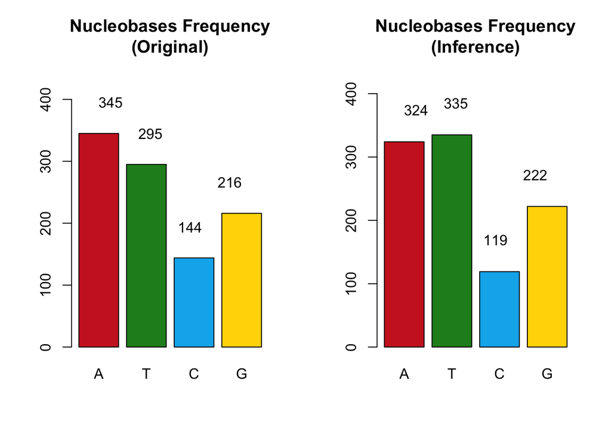

```r
par(mfrow=c(1,2))
barplot(seq.summary, main='Nucleobases Frequency\n(Original)', ylim=c(0,max(seq.summary)+100),
        col=c('firebrick3','forestgreen','deepskyblue2','gold'))
text(seq.summary+50, labels = seq.summary)

barplot(seq2.summary, main='Nucleobases Frequency\n(Inference)', ylim=c(0,max(seq2.summary)+100),
        col=c('firebrick3','forestgreen','deepskyblue2','gold'))
text(seq2.summary+50, labels = seq2.summary)
```

- Comparando as densidades:

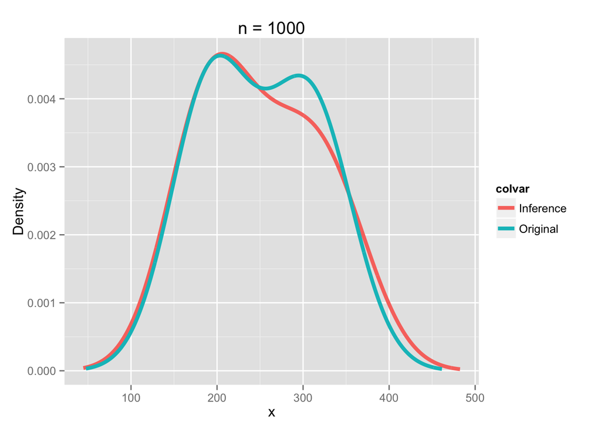

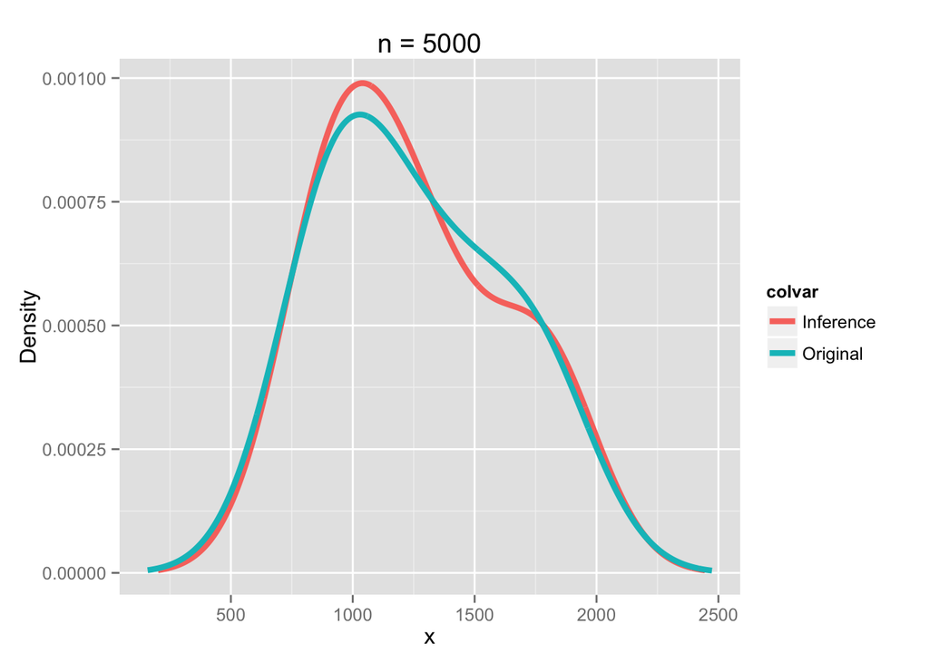

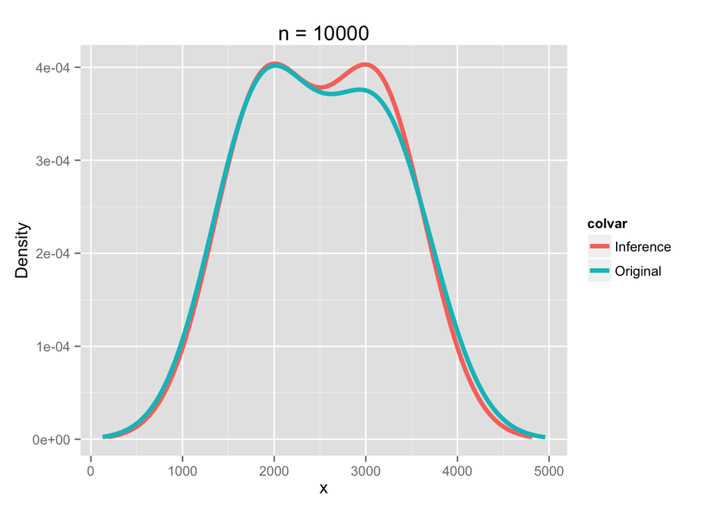

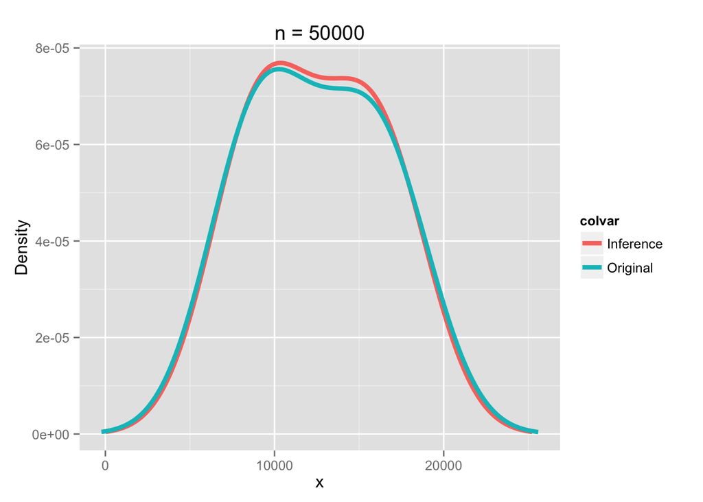

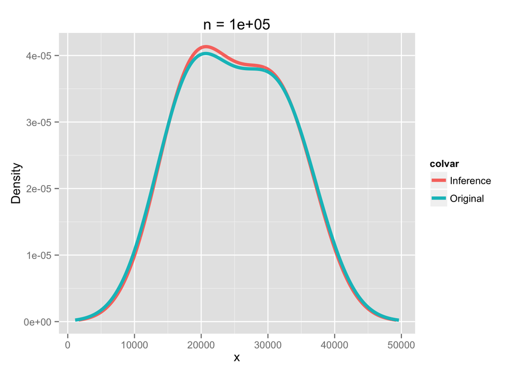

```r
#generates density plot for sample size = n
compareDensity <- function(n){
  seq <- generateSequence(n, probMatrix)
  seq.summary <- summarySeq(seq)
  infMatrix <- generateMatrix(seq)
  seq2 <- generateSequence(n, infMatrix)
  seq2.summary <- summarySeq(seq2)
  x <- data.frame(x = density(seq.summary)$x,y = density(seq.summary)$y)
  y <- data.frame(x = density(seq2.summary)$x,y = density(seq2.summary)$y)
  dat <- data.frame(rbind(x, y),
                    colvar=factor(c(rep("Original", nrow(x)), rep("Inference", nrow(y)))))
  g <- ggplot(dat, aes(x = x, y = y))
  g <- g + geom_line(size = 1.5, aes(colour = colvar))
  g + labs(title = paste('n =', n), y = 'Density')
}
```

Assim demonstramos a afirmativa do vídeo, na qual o número de vezes que cada estado é visitado converge para uma probabilidade específica. Maior o número de visitas, mais semelhante é a distribuição da probabilidade.

# Questão 2

- Primeiro geramos dados aleatórios:

```r
col = n = 20
row = 50
dat = matrix(0, nrow=row, ncol=col)
for(i in 1:row){
    for(j in 1:col){
      dat[i,j] = sample(1:1000, 1, replace=TRUE)
    }
}
```

- Implementação do método de agrupamento hierárquico com distância Aitichisoneana:

```r
aitchiDistance <- function(dat){
  dat <- dat/sum(dat) #normalization (total sum = 1)
  d <- nrow(dat)
  aitchi <- matrix(0, nrow=nrow(dat), ncol=ncol(dat))
  for(i in 1:nrow(dat)){
    for(j in 1:ncol(dat)){
      a <- dat[i,]
      b <- dat[,j]
      sum <- 0
      for(k in 1:(d-1)){
            sum <- sum + (log(a[k]/a[d]) - log(b[k]/b[d]))^2
      }
        aitchi[i,j] <- sqrt(sum)
    }
  }#end loop
  return(aitchi)
}

#applying Aitchisonean distance
aDistance <- aitchiDistance(t(dat))

#converting to dissimilarity matrix object
aDistance <- aDistance[1:(n*(n-1)/2)] #lower triangle
class(aDistance) <- 'dist'
attr(aDistance,"Size") <- n
aDistance <- as.dist(aDistance)
```

- Comparando os métodos:

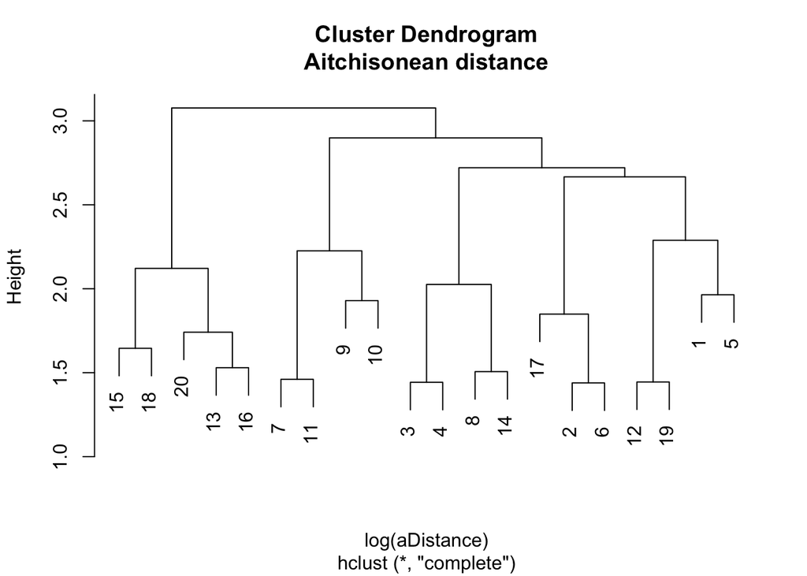

```r
# Aitchisonean distance
plot(hclust(log(aDistance)), main = 'Cluster Dendrogram\nAitchisonean distance')
```

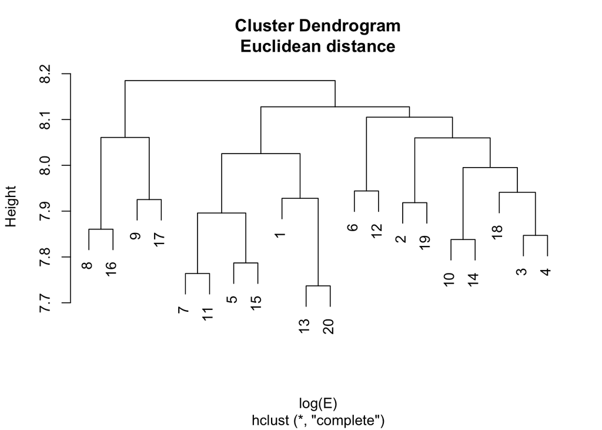

```r
# Euclidean distance
E = dist(t(dat))
plot(hclust(log(E)), main = 'Cluster Dendrogram\nEuclidean distance')
```

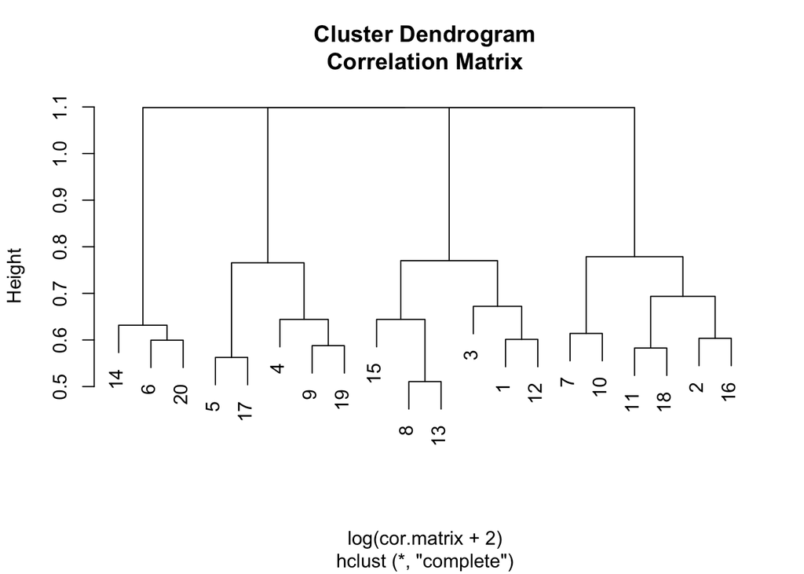

```r
# Correlation Matrix
cor.matrix <- cor(dat)
cor.matrix <- cor.matrix[1:(n*(n-1)/2)]
class(cor.matrix) <- 'dist'
attr(cor.matrix,"Size") <- n
cor.matrix<-as.dist(cor.matrix)
plot(hclust(log(cor.matrix+2) ), main = 'Cluster Dendrogram\nCorrelation Matrix')
```

# Questão 3

- Implementando a solução proposta no fórum para N dimensões:

```r
clusterND <- function(n=2, size=70000){
  #create inital matrix
  dat <- rbind(matrix(rnorm(size, sd = 0.3), ncol = 2),
             matrix(rnorm(size, mean = 1, sd = 0.3), ncol = 2))
  colnames(dat) <- letters[1:2]

  #increase dimension
  if(n>=3 )
    for(i in 3:n){
      dat <- cbind(dat, matrix(rnorm(size, sd = 0.3), ncol = 1))
      colnames(dat) <- letters[1:i]
    }

  #create cluster
  cl <- kmeans(dat, 1000, iter.max=20)
  cah <- HCPC(data.frame(cl$centers), graph=FALSE, nb.clust=-1)

  #plot
  plot.HCPC(cah, choice="tree", main = paste('n =', n))
}
```

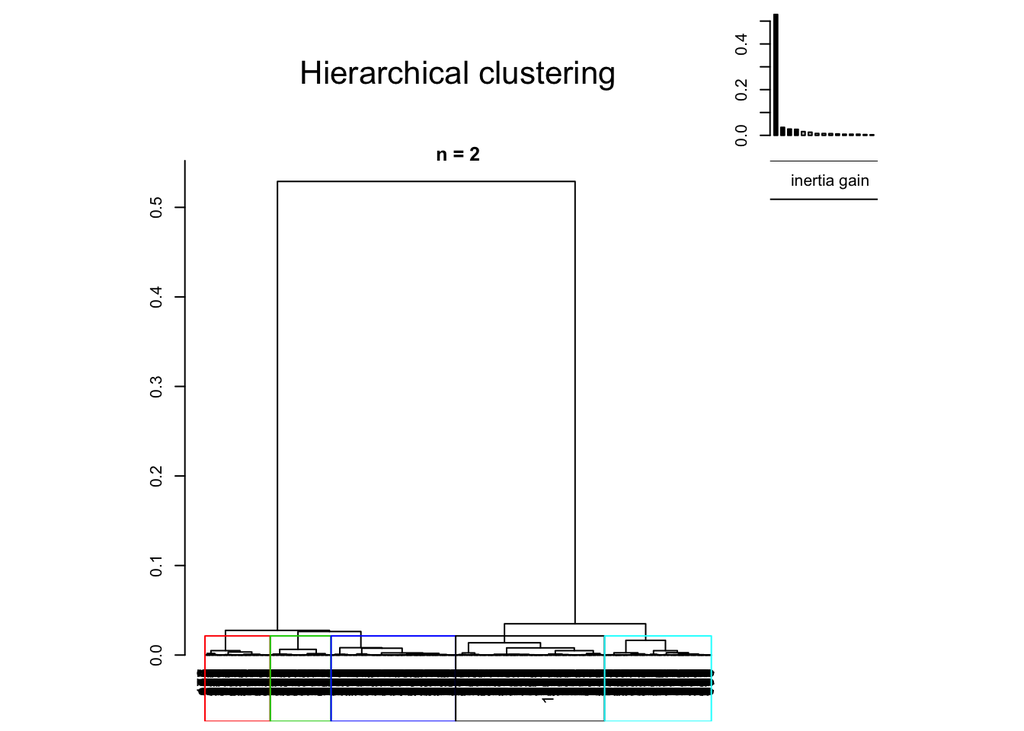

```r
#2-D
clusterND(2)
```

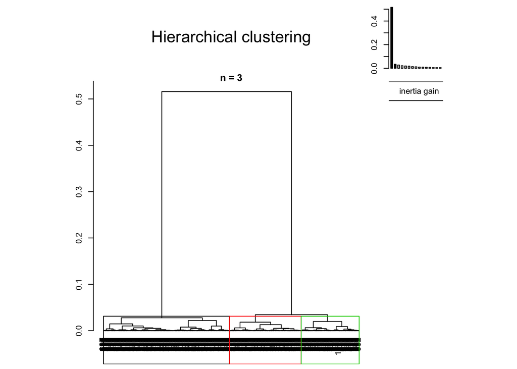

```r
#3-D
clusterND(3)
```

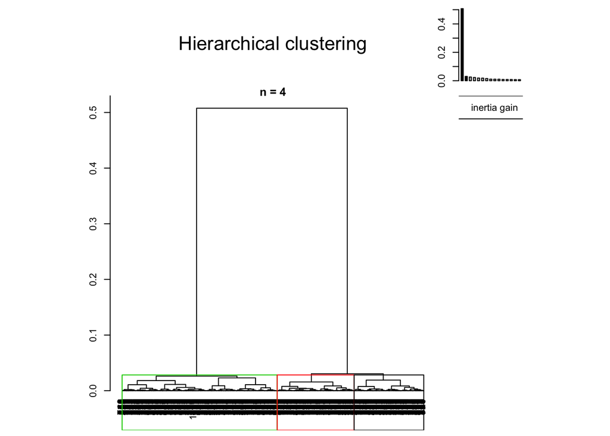

```r
#4-D
clusterND(4)
```

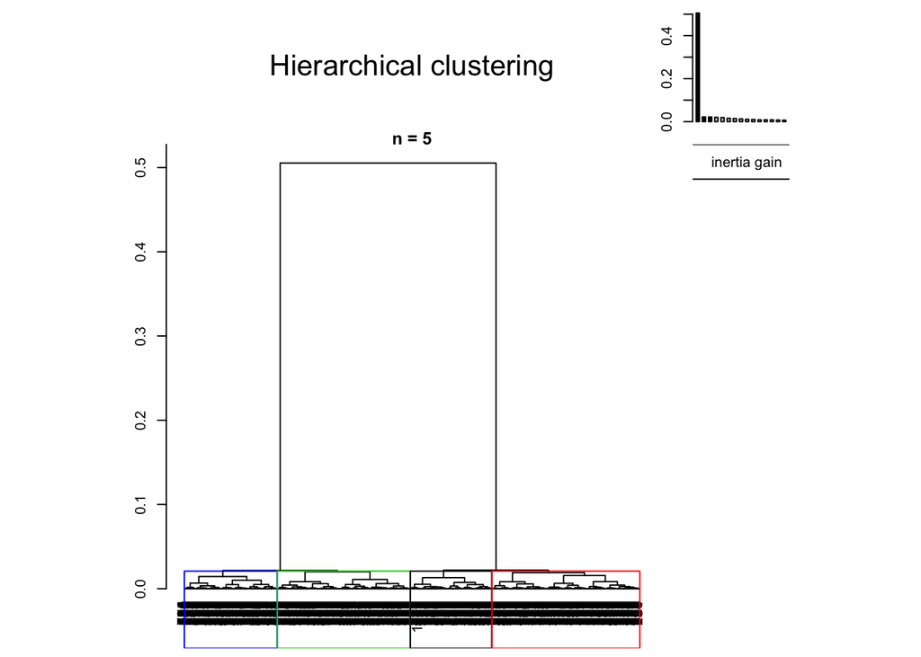

```r
#5-D
clusterND(5)
```

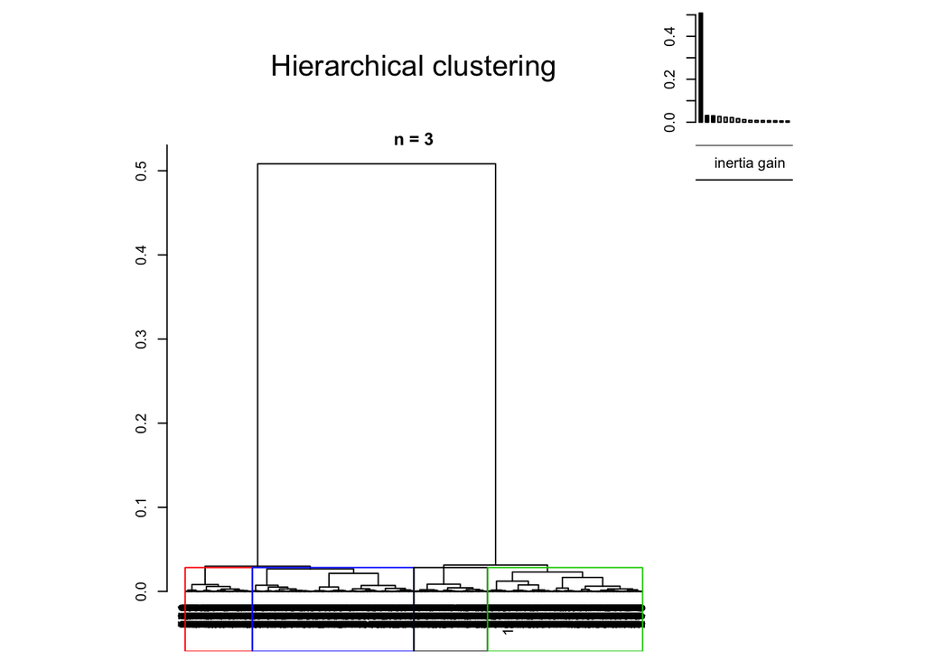

```r
#changing size of lines to 100000
clusterND(n = 3, size = 100000)
```

O usuário quis dizer que o tamanho dos dados sendo utilizados não era grande nem pequeno, o problema estava na abordagem orientada à matriz para resolver este problema, pois demandam uma alta complexidade computacional, i.e. O(n<sup>2</sup>) ou até mesmo O(n<sup>3</sup>), se comparada com outros algoritmos que nem usam matrizes.  
Uma solução apresentada é usar o software de mineração de dados ELKI, ótimo para métodos não-supervisionados em análises de clusters e detecção de outliers, por ser baseado em estrutura de índices, como a [R-Tree](https://en.wikipedia.org/wiki/R-tree).  
Caso o questionador insista em utilizar o R, o pacote `fastcluster` é sugerido por usar o método de clusterização K-means, que possui uma complexidade O(nki), onde: k = parâmetro k; e i o número e iterações (método comparável ao Slink no ELKI).  
Também é recomendado que se o dado por 1-dimensional, não é necessário usar clusterização, ao invés disso usa-se a estimação de densidade do kernel, pelo fato dos dados estarem ordenados.  
Para concluir, é lembrado que o foco do R esta na parte de expressividade estatística e não escalabilidade, não sendo assim a ferramenta mais recomendada para mexer com dados enormes.